# DSCOE Inferno #2 Boogie Wonderland

Wednesday, May 18, 2016

## What is Data Science?

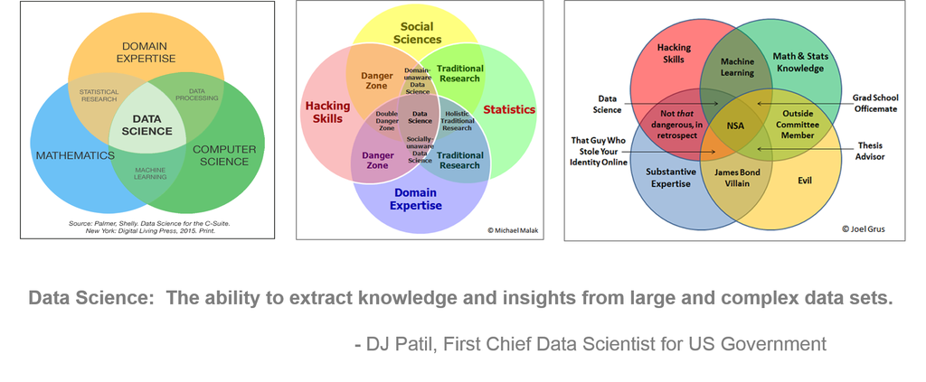

## The Two Tribes of Data Science

[figure not shown]

## Why Data Science Now?

**The rise in data science has been driven by the merging of several disciplines into one meta-discipline and several significant shifts in foundational disciplines:**

- **Computer Science / Software Engineering:**
  - [Git Repos](https://github.com/) and [Open Source Projects](http://www.apache.org/)
  - (Massively) [Parallel Computing](https://en.wikipedia.org/wiki/Parallel_computing)
  - [Big Data](http://www.sas.com/en_us/insights/big-data/what-is-big-data.html)
  - [Amazon Web Services](https://aws.amazon.com/) ([Cloud Computing](https://en.wikipedia.org/wiki/Cloud_computing))
- **Math / Statistics:** Rise of **open source software communities** ([R](https://www.r-project.org/), [Julia](http://julialang.org/benchmarks/), etc.) for math and statistics.
- **Data Visualization (vs. Graphics):** Use of a **more powerful medium** (html vs Word) to communicate the insights contained in models/data (many examples to be shown today).

## How We Define Data Science

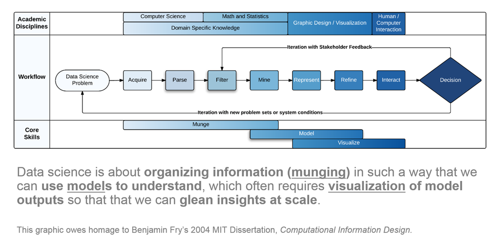

## The Bigger Picture: Analytics Process

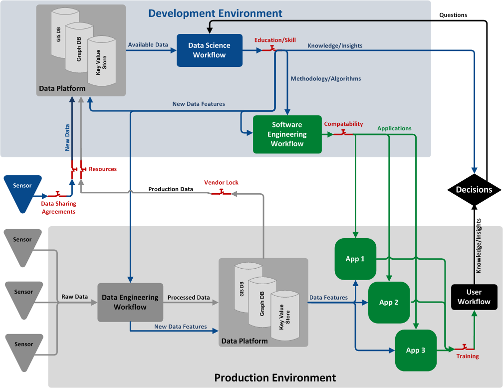

**Analytics connect sensors to decisions.**

## How Do I Become a Data Scientist?

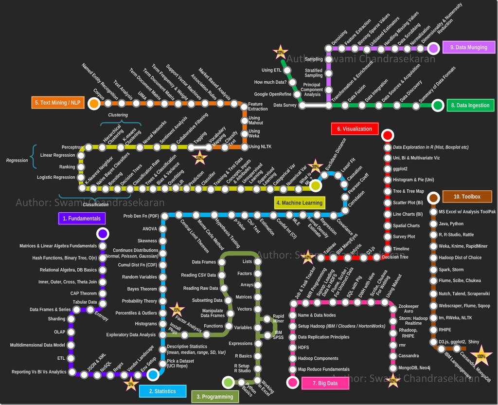

```
- Source: https://datafloq.com/read/long-road-big-data-scientist-infographic/423
```

## No Really - How Do I Become a Data Scientist?

- If you aren't moving forward, you're moving backwards (learn something every day).
- DS requires a mix of **education** (understanding of concepts) and **training** (a collection of skills).
- Google, stack overflow, curiousity and perserverance can often substitute for specific training (just get after it); education is hard to sub.
- **Master the fundamentals first: statistics and programming (R or Python).**
- Master one language (R recommended for ORSAs) before adding another (Python, Scala, javascript, etc.).
- Data science is a team sport: join a team!
- **Read, learn, comment, contribute: dscoe.army.mil.**

## Expectation Management

**What you should not expect from today:**

- A comprehensive review
- A class on how to program
- A class that troubleshoots your code
- Any in-depth analysis or math review

**What you should expect from today:**

- A very interactive experience
- Try the code!
- Follow the links!
- A collection of reproducible examples
- A forum to ask questions
- Access to folks who are doing this stuff now (network)
- A better understanding of data science
- A head start on building your skill set!

## What We Are Going To Do Today

Website: http://dscoe.github.io/

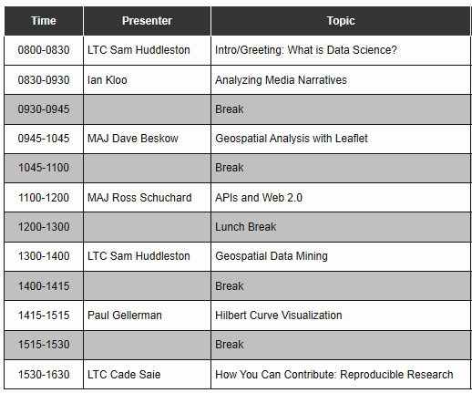

## Let's Get Going!

[figure not shown]